# Analysis of Factors Causing Long Trips in San Fransisco

## by Shadrack T. Adeyemi

## Investigation Overview

For the presentation, I focused on some factors that affect the long trips of bike riders in San Fransisco. The main features of interest are the time and day of the week, the user types and the gender of members.

## Dataset Overview

This dataset contains information of over 183,000 bike rides of a bike-sharing system in the greater San Fransisco Bay Area. This data set has information about individual rides during the month of February, with features such as durations, member gender, customer type, amongst others.

## Trip Frequency Distribution of the Time and Day

These plot show a bimodal distribution, with the most frequent rides taken between 8am-9am and 5pm-6pm and mostly on Thursdays.

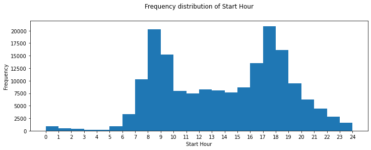

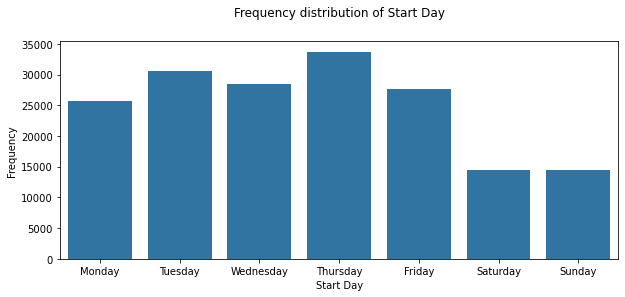

## Further Investigation into the Trip Duration of the Time and Day

A facetgrid of the trip duration for each start hour at everyday is plotted to investigate further. After the plot I realised more information on the time and day trip frequency, where at weekdays the distribution is bimodal, and unimodal at weekends. Also at weekends, the time for most trips occurred between 1pm and 3pm.

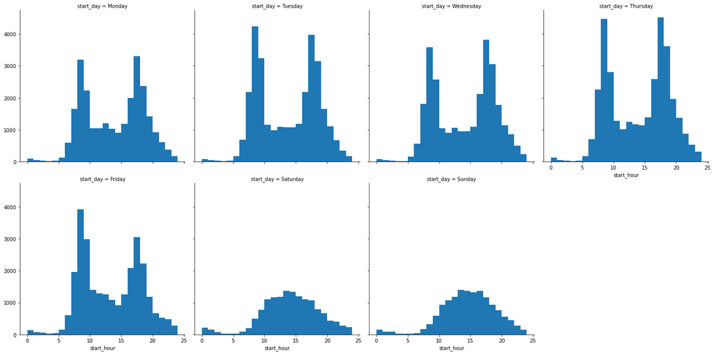

## Frequency Distribution of Average Trip Duration for Member Genders

This multivariate histogram chart shows that the 'Other' gender despite having the least frequent riders have the highest average trip duration at 11.43 minutes, with the 'Female' gender coming in a close at 11.26 minutes. The assumption made in this analysis is that the 'Other' gender represents LGBTQ+.

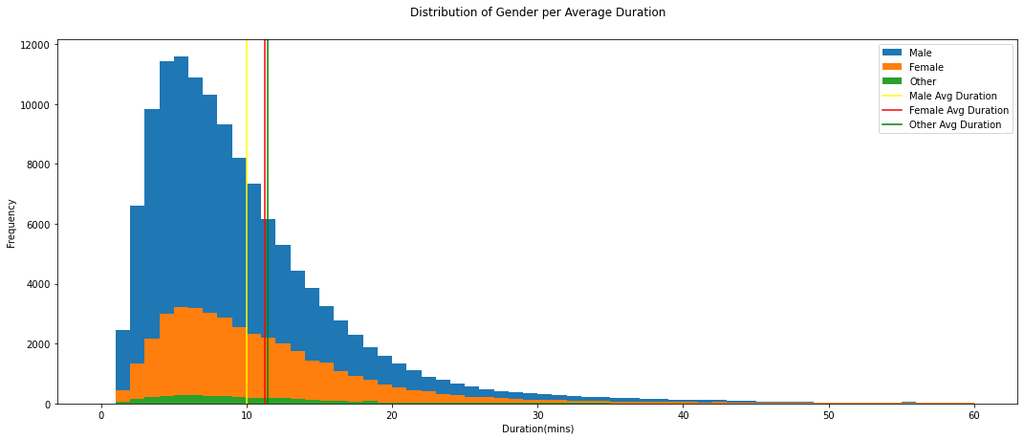